# Web Traffic Model Example

Harry He

2026-07-26

### Purpose of vignette

This vignette illustrates `capnet` in a domain other than finance: forecasting daily aggregate Wikipedia traffic from a panel of individual, heavy-tailed article-level pageview series. Article popularity on the web is famously Zipf/heavy-tailed – a small number of articles can go “viral” and receive orders of magnitude more traffic than usual on a given day. A linear (here, Poisson) forecasting model that regresses tomorrow’s site-wide traffic on today’s per-article pageviews is exactly the setting `capnet` targets: without a contribution cap, a single freak spike in one article’s traffic can swamp the forecast, even though the underlying coefficient is not unusually large under a standard elastic-net fit.

### Data

The dataset (`inst/extdata/wiki_traffic.csv`) contains daily English Wikipedia pageviews (2022-01-01 to 2024-12-31) for 30 widely-read articles (major tech companies, AI/crypto topics, and prominent public figures), pulled from the public Wikimedia Pageviews REST API. The response is *next-day* total pageviews summed across all 30 articles; the covariates are *today’s* per-article pageviews (in thousands of views, for numerical scaling). The `total` column is dropped from the covariate set since it is an exact linear combination of the 30 article columns.

```r
wiki <- read.csv(system.file("extdata", "wiki_traffic.csv", package = "capnet"))
wiki$date <- as.Date(wiki$date)

articles <- setdiff(names(wiki), c("date", "total"))

wiki <- wiki |>
  arrange(date) |>
  mutate(target = dplyr::lead(total, 1)) |>
  filter(!is.na(target)) |>
  mutate(across(all_of(articles), ~ . / 1000)) |>   # thousands of views
  select(date, target, all_of(articles))

print(calc_moments(wiki[, articles]))
```

```
##                   variable       mean     variance excess_kurtosis
## 1                    apple  12.261544 1.902069e+01      56.2106066
## 2                   google  33.130276 1.847081e+02      25.1941345
## 3                microsoft   9.095185 2.295141e+02    1034.9635327
## 4                   amazon  15.716311 3.427888e+01       1.0933171
## 5                     meta  15.704444 8.911856e+01       0.7407420
## 6                    tesla   8.460263 1.092988e+01      37.7697321
## 7                   nvidia   5.605834 3.720858e+01      69.7379955
## 8                   openai  12.216690 1.654244e+02      15.6533248
## 9                  chatgpt  66.750111 6.108049e+03       2.0631917
## 10 artificial_intelligence  15.391548 1.860638e+01      -0.4050504
## 11                 bitcoin   6.989986 1.003581e+01      16.7186200
## 12                ethereum   2.061052 1.925581e+00      11.9147578
## 13          cryptocurrency   4.392612 5.006687e+00      29.0228783
## 14                 netflix  18.477065 4.086947e+01      -0.8511692
```

[output cut: 16 more lines]

The summary statistics show pronounced positive excess kurtosis for several articles (e.g. `sam_altman`, `elon_musk`, `nvidia`), confirming that a handful of articles experience occasional traffic spikes far outside their typical range – precisely the covariate behavior contribution caps are designed to control.

### Backtest

We forecast next-day total pageviews with a Poisson log-link model, using a rolling one-year training window refit monthly (steps of 5 days within each month, to keep runtime moderate) and evaluated out-of-sample from 2023-01-01 through 2024-12-31. Refit months are independent of one another, so `rolling_enet()` dispatches them across CPU cores via `parallel = TRUE`. Because Poisson deviance scales with the (very large) raw pageview counts, we set `alpha = 0` and forgo elastic-net selection entirely (`lambda = 0`) so that the comparison isolates the effect of the contribution cap alone, exactly mirroring the role `gamma` plays in the finance example.

Contribution ceilings are computed the same way as in the finance vignette: as a multiple of each feature’s univariate regression coefficient with the response, here using a univariate Poisson GLM slope (the natural analogue of the OLS slope used for the Gaussian model) rather than the raw correlation.

```r
wiki_L <- function(train_use, target_col, feature_cols, y_train) {
  sapply(feature_cols, function(v) {
    uni <- suppressWarnings(
      stats::glm(train_use[[target_col]] ~ train_use[[v]], family = "poisson")
    )
    3 * abs(stats::coef(uni)[2])
  })
}

results <- rolling_enet(
  wiki,
  date_col = "date",
  target_col = "target",
  alpha = 0,
  window_years = 1,
  method = c("capnet_walk", "capnet", "postcap"),
  capnet_gamma = c(0),
  walk_gamma = c(10, 100, 1000, 10000, 100000),
  min_obs = 200,
  eval_start = "2023-01-01",
  family = "poisson",
  cap_formula = wiki_L,
  lambda_override = 0,
  walk = 5,
  parallel = TRUE
)

combos <- results$predictions %>%
  dplyr::distinct(method, gamma) %>%
  dplyr::arrange(method, gamma)

predictions <- list()
contributions <- list()
methods <- c()
gamma_vals <- c()

for (i in seq_len(nrow(combos))) {
  m <- combos$method[i]
  gamma_j <- combos$gamma[i]

  predictions[[i]] <- results$predictions %>%
    dplyr::filter(method == m, gamma == gamma_j)
  contributions[[i]] <- results$contributions %>%
    dplyr::filter(method == m, gamma == gamma_j)
  methods[i] <- m
  gamma_vals[i] <- gamma_j
}
```

```
## # A tibble: 7 × 3
##   method               gamma     oos_r2
##   <chr>                <dbl>      <dbl>
## 1 Post-Fit Cap            NA    -1.43
## 2 Uncapped                NA -9461.
## 3 Walk-forward Capnet     10  -602.
## 4 Walk-forward Capnet    100    -0.0661
## 5 Walk-forward Capnet   1000     0.408
## 6 Walk-forward Capnet  10000     0.438
## 7 Walk-forward Capnet 100000     0.410
```

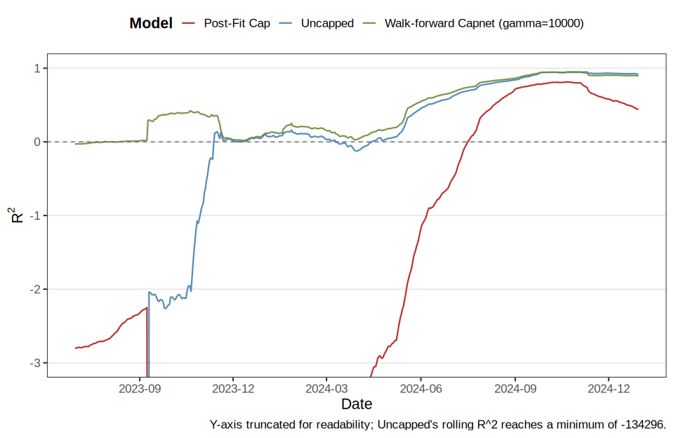

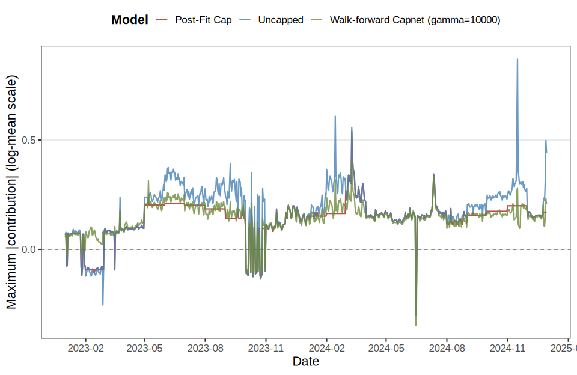

### Contribution redistribution snapshot

```r
tab <- make_feature_table(
  df_list = list(contributions[[which(methods == "Uncapped")[1]]],
                 contributions[[which(methods == "Post-Fit Cap")[1]]],
                 contributions[[sel[length(sel)]]]),
  target_date = as.Date("2023-03-14"),
  df_names = c("Uncapped", "Post-Fit Cap", walk_label),
  feature_cols = articles
)

print(tab)
```

```
##                    feature     Uncapped  Post-Fit Cap
## 1                    apple  0.052217071  0.0076504940
## 2                   google  0.065221467  0.0046095447
## 3                microsoft -0.046480383 -0.0464803830
## 4                   amazon  0.019359071  0.0086006248
## 5                     meta  0.040798227  0.0029166713
## 6                    tesla  0.050898949  0.0508989491
## 7                   nvidia -0.028993042 -0.0289930424
## 8                   openai  0.050405565  0.0182695242
## 9                  chatgpt  0.364917460  0.0037990426
## 10 artificial_intelligence  0.026206457  0.0026481768
## 11                 bitcoin -0.021238039 -0.0122903711
## 12                ethereum  0.008528942  0.0085289425
## 13          cryptocurrency  0.047375164  0.0384974443
## 14                 netflix  0.150454186  0.0296639839
```

[output cut: 47 more lines]

As in the finance example, the post-fit approach truncates the offending contribution mechanically without adjusting any other coefficient, while the walk-forward `capnet` model redistributes weight across multiple articles, reflecting a genuinely re-estimated (rather than post-hoc clipped) fit.